# Evaluation criteria - Medical Insurance Cost Data

```r
str(medical_insurance)
```

```
## 'data.frame':    2772 obs. of  7 variables:
##  $ age     : int  19 18 28 33 32 31 46 37 37 60 ...
##  $ sex     : chr  "female" "male" "male" "male" ...
##  $ bmi     : num  27.9 33.8 33 22.7 28.9 ...
##  $ children: int  0 1 3 0 0 0 1 3 2 0 ...
##  $ smoker  : chr  "yes" "no" "no" "no" ...
##  $ region  : chr  "southwest" "southeast" "southeast" "northwest" ...
##  $ charges : num  16885 1726 4449 21984 3867 ...
```

```r
summary(medical_insurance)
```

```
##       age            sex                 bmi           children
##  Min.   :18.00   Length:2772        Min.   :15.96   Min.   :0.000
##  1st Qu.:26.00   Class :character   1st Qu.:26.22   1st Qu.:0.000
##  Median :39.00   Mode  :character   Median :30.45   Median :1.000
##  Mean   :39.11                      Mean   :30.70   Mean   :1.102
##  3rd Qu.:51.00                      3rd Qu.:34.77   3rd Qu.:2.000
##  Max.   :64.00                      Max.   :53.13   Max.   :5.000
##     smoker             region             charges
##  Length:2772        Length:2772        Min.   : 1122
##  Class :character   Class :character   1st Qu.: 4688
##  Mode  :character   Mode  :character   Median : 9333
##                                        Mean   :13261
##                                        3rd Qu.:16578
##                                        Max.   :63770
```

# Resemblance

## Alpha precision, beta recall, authenticity

### m = 5

```r
more_criteria_medical_insurance_precision_recall_authenticity_m5 <- more_criteria_medical_insurance_precision_recall_authenticity %>% filter(M == 5)

# Create the table using kable
kable(more_criteria_medical_insurance_precision_recall_authenticity_m5, format = "markdown", caption = "Results Table")
```

Results Table

| Method | M | AlphaPrecision | BetaRecall | Authenticity |
| --- | --- | --- | --- | --- |
| synthpop | 5 | 0.8954545 | 0.8998557 | 1 |
| arf | 5 | 0.8990620 | 0.8997114 | 1 |
| privbayes | 5 | 0.9013709 | 0.8997114 | 1 |
| ctgan | 5 | 0.8904040 | 0.8997114 | 1 |
| tvae | 5 | 0.8927850 | 0.8998557 | 1 |
| tabsyn | 5 | 0.8948052 | 0.8997114 | 1 |

### m = 10

```r
more_criteria_medical_insurance_precision_recall_authenticity_m10 <- more_criteria_medical_insurance_precision_recall_authenticity %>% filter(M == 10)

# Create the table using kable
kable(more_criteria_medical_insurance_precision_recall_authenticity_m10, format = "markdown", caption = "Results Table")
```

Results Table

| Method | M | AlphaPrecision | BetaRecall | Authenticity |
| --- | --- | --- | --- | --- |
| synthpop | 10 | 0.8957071 | 0.8997835 | 1 |
| arf | 10 | 0.8989538 | 0.8997114 | 1 |
| privbayes | 10 | 0.9020202 | 0.8997114 | 1 |
| ctgan | 10 | 0.8905844 | 0.8997114 | 1 |
| tvae | 10 | 0.8937229 | 0.8997835 | 1 |
| tabsyn | 10 | 0.8941558 | 0.8997835 | 1 |

### m = 50

```r
more_criteria_medical_insurance_precision_recall_authenticity_m50 <- more_criteria_medical_insurance_precision_recall_authenticity %>% filter(M == 50)

# Create the table using kable
kable(more_criteria_medical_insurance_precision_recall_authenticity_m50, format = "markdown", caption = "Results Table")
```

Results Table

| Method | M | AlphaPrecision | BetaRecall | Authenticity |
| --- | --- | --- | --- | --- |
| synthpop | 50 | 0.8955267 | 0.8997258 | 1 |
| arf | 50 | 0.8987374 | 0.8997114 | 1 |
| privbayes | 50 | 0.9028499 | 0.8997258 | 1 |
| ctgan | 50 | 0.8905844 | 0.8997114 | 1 |
| tvae | 50 | 0.8944661 | 0.8997258 | 1 |
| tabsyn | 50 | 0.8944949 | 0.8997258 | 1 |

## Classifier two-sample test (C2ST)

Note: I have specified the limits of the y axis from 0.4 to 1. This is probably not the best option as some boxplots get very thin because of the big range but a consistent range for all plots would be nice.

### KNN

#### Accuracy

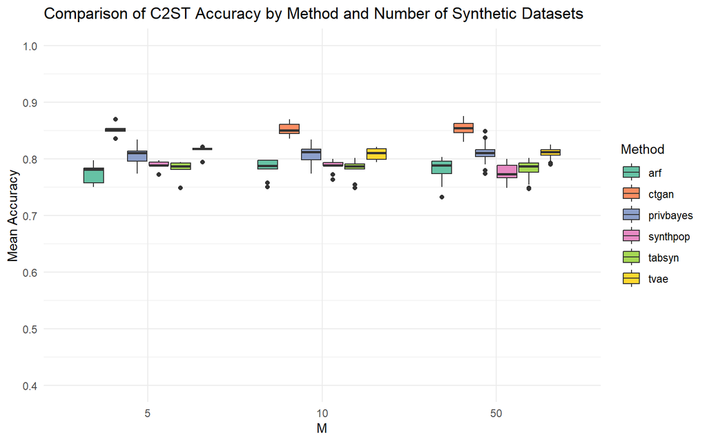

```r
more_criteria_medical_insurance_c2st_knn <- more_criteria_medical_insurance_c2st %>% filter(Classifier == "KNN")

# Boxplot erstellen
plot_medical_insurance_c2st <-ggplot(more_criteria_medical_insurance_c2st_knn, aes(x = factor(M), y = C2ST_Accuracy, fill = Method)) +
  geom_boxplot() +
  labs(title = "Comparison of C2ST Accuracy by Method and Number of Synthetic Datasets",
       x = "M",
       y = "Mean Accuracy") +
  theme_minimal() +
  scale_fill_brewer(palette = "Set2") +
  scale_y_continuous(limits = c(0.4, 1), breaks = seq(0.4, 1, by = 0.1))
plot_medical_insurance_c2st
```

Interpretation in general:

- Accuracy ~ 50% -> p-value high (> 0.05) -> $H_0$ is not rejected -> same distributions
- Accuracy ~ 55%-65% -> p-value moderate (= 0.05) -> weak evidence of difference
- Accuracy ~ 65%-80% -> p-value low (< 0.05) -> $H_0$ is rejected -> evidence that distributions are different
- Accuracy ~ 80%-100% -> p-value very low (< 0.001) -> $H_0$ is rejected -> samples are from distinct distributions

#### AUC

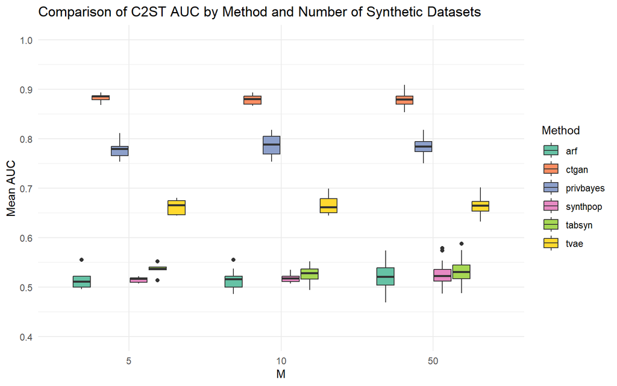

```r
# Boxplot erstellen
plot_medical_insurance_c2st <-ggplot(more_criteria_medical_insurance_c2st_knn, aes(x = factor(M), y = AUC, fill = Method)) +
  geom_boxplot() +
  labs(title = "Comparison of C2ST AUC by Method and Number of Synthetic Datasets",
       x = "M",
       y = "Mean AUC") +
  theme_minimal() +
  scale_fill_brewer(palette = "Set2") +
  scale_y_continuous(limits = c(0.4, 1), breaks = seq(0.4, 1, by = 0.1))
plot_medical_insurance_c2st
```

### RF

#### Accuracy

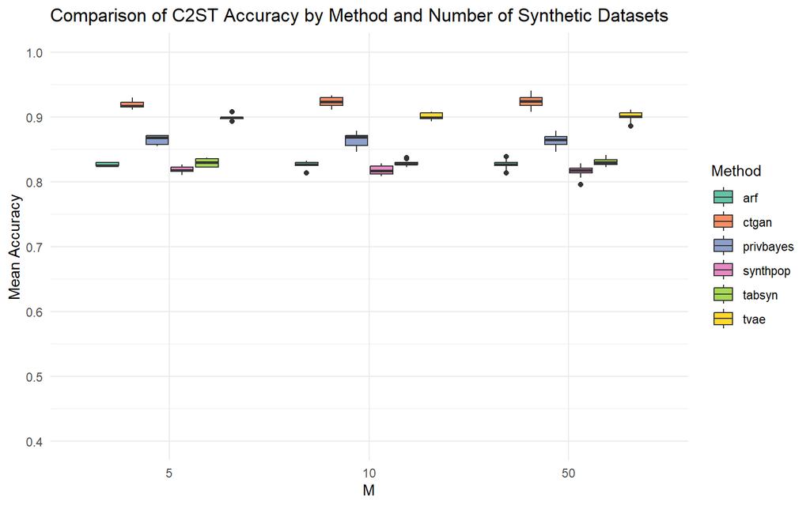

```r
more_criteria_medical_insurance_c2st_rf <- more_criteria_medical_insurance_c2st %>% filter(Classifier == "RF")

# Boxplot erstellen
plot_medical_insurance_c2st <- ggplot(more_criteria_medical_insurance_c2st_rf, aes(x = factor(M), y = C2ST_Accuracy, fill = Method)) +
  geom_boxplot() +
  labs(title = "Comparison of C2ST Accuracy by Method and Number of Synthetic Datasets",
       x = "M",
       y = "Mean Accuracy") +
  theme_minimal() +
  scale_fill_brewer(palette = "Set2") +
  scale_y_continuous(limits = c(0.4, 1), breaks = seq(0.4, 1, by = 0.1))
plot_medical_insurance_c2st
```

#### AUC

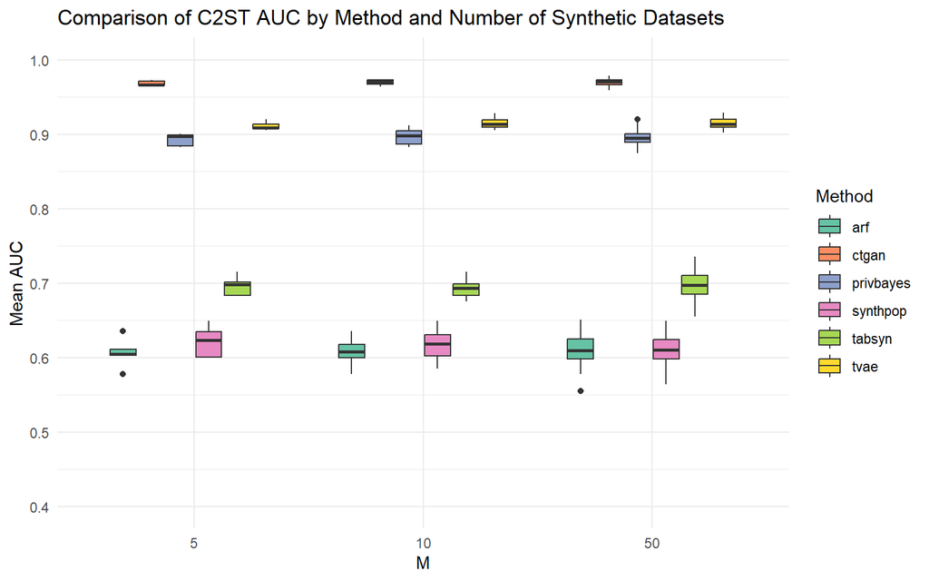

```r
# Boxplot erstellen
plot_medical_insurance_c2st <-ggplot(more_criteria_medical_insurance_c2st_rf, aes(x = factor(M), y = AUC, fill = Method)) +
  geom_boxplot() +
  labs(title = "Comparison of C2ST AUC by Method and Number of Synthetic Datasets",
       x = "M",
       y = "Mean AUC") +
  theme_minimal() +
  scale_fill_brewer(palette = "Set2") +
  scale_y_continuous(limits = c(0.4, 1), breaks = seq(0.4, 1, by = 0.1))
plot_medical_insurance_c2st
```

### NN

#### Accuracy

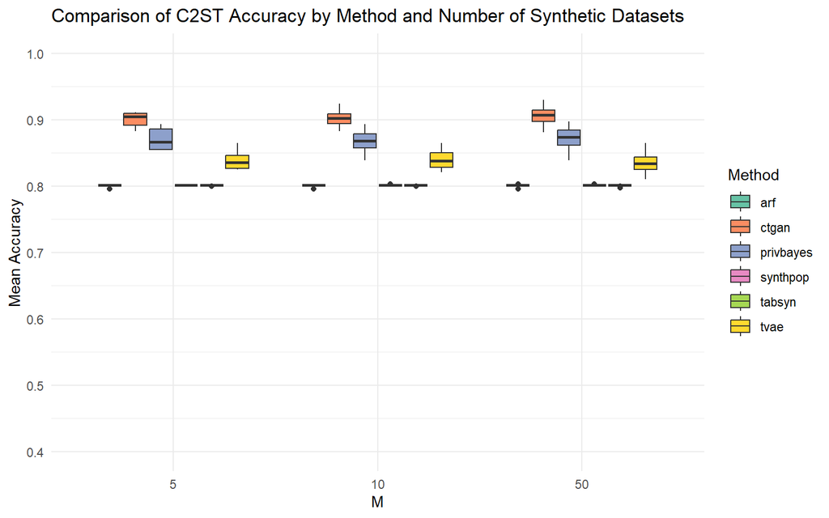

```r
more_criteria_medical_insurance_c2st_nn <- more_criteria_medical_insurance_c2st %>% filter(Classifier == "NN")

# Boxplot erstellen
plot_medical_insurance_c2st <-ggplot(more_criteria_medical_insurance_c2st_nn, aes(x = factor(M), y = C2ST_Accuracy, fill = Method)) +
  geom_boxplot() +
  labs(title = "Comparison of C2ST Accuracy by Method and Number of Synthetic Datasets",
       x = "M",
       y = "Mean Accuracy") +
  theme_minimal() +
  scale_fill_brewer(palette = "Set2") +
  scale_y_continuous(limits = c(0.4, 1), breaks = seq(0.4, 1, by = 0.1))
plot_medical_insurance_c2st
```

#### AUC

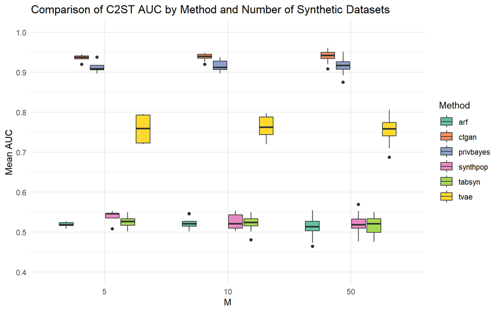

```r
# Boxplot erstellen
plot_medical_insurance_c2st <-ggplot(more_criteria_medical_insurance_c2st_nn, aes(x = factor(M), y = AUC, fill = Method)) +
  geom_boxplot() +
  labs(title = "Comparison of C2ST AUC by Method and Number of Synthetic Datasets",
       x = "M",
       y = "Mean AUC") +
  theme_minimal() +
  scale_fill_brewer(palette = "Set2") +
  scale_y_continuous(limits = c(0.4, 1), breaks = seq(0.4, 1, by = 0.1))
plot_medical_insurance_c2st
```

# Utility

## Statistical Utility

Note: The colors still have to be changed to be consistent with the other plots.

[figure not shown]

## ML Utility

Es wird beurteilt, wie gut Modelle, die mit synthetischen Daten trainiert wurden, auf echten Daten performen. Bei Klassifikationsaufgaben werden Accuracy und/oder F1-Score betrachtet, während bei Regressionsaufgaben der R²-Wert (Bestimmtheitsmaß) betrachtet wird.

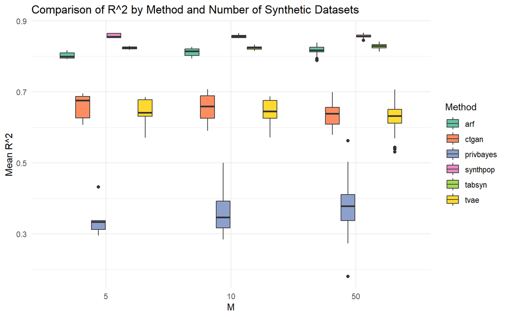

```r
# Boxplot erstellen - R^2
plot_medical_insurance_ml_utility_r_squared <- ggplot(more_criteria_medical_insurance_ml_utility, aes(x = factor(M), y = R2, fill = Method)) +
  geom_boxplot() +
  labs(title = "Comparison of R^2 by Method and Number of Synthetic Datasets",
       x = "M",
       y = "Mean R^2") +
  theme_minimal() +
  scale_fill_brewer(palette = "Set2")
plot_medical_insurance_ml_utility_r_squared
```

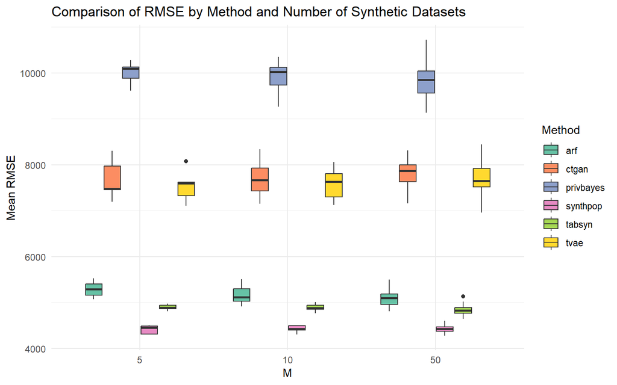

```r
# Boxplot erstellen - RMSE
plot_medical_insurance_ml_utility_rmse <- ggplot(more_criteria_medical_insurance_ml_utility, aes(x = factor(M), y = RMSE, fill = Method)) +
  geom_boxplot() +
  labs(title = "Comparison of RMSE by Method and Number of Synthetic Datasets",
       x = "M",
       y = "Mean RMSE") +
  theme_minimal() +
  scale_fill_brewer(palette = "Set2")
plot_medical_insurance_ml_utility_rmse
```

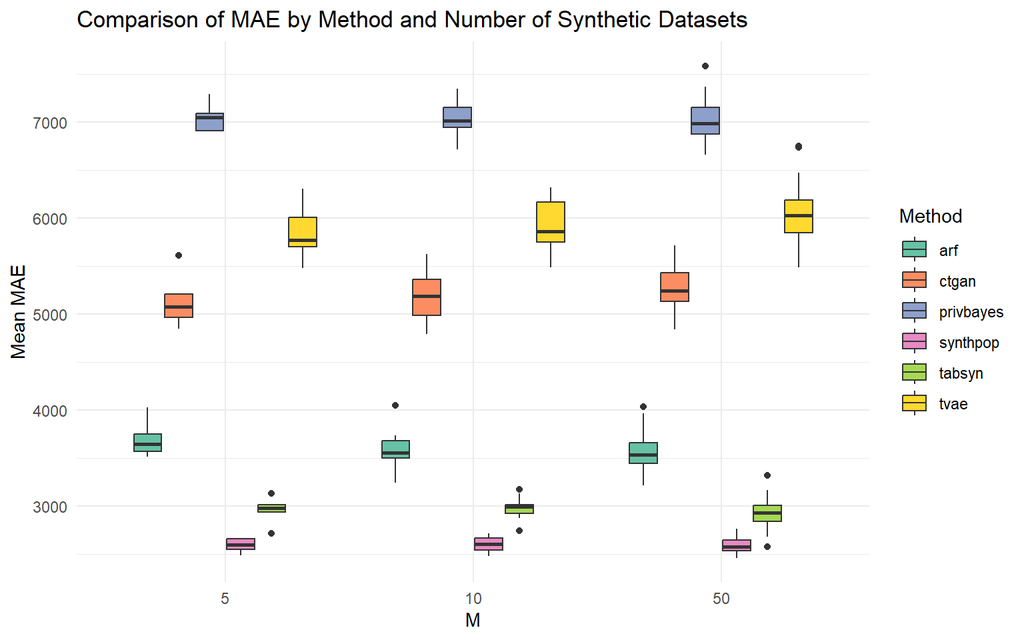

```r
# Boxplot erstellen - MAE
plot_medical_insurance_ml_utility_mae <- ggplot(more_criteria_medical_insurance_ml_utility, aes(x = factor(M), y = MAE, fill = Method)) +
  geom_boxplot() +
  labs(title = "Comparison of MAE by Method and Number of Synthetic Datasets",
       x = "M",
       y = "Mean MAE") +
  theme_minimal() +
  scale_fill_brewer(palette = "Set2")
plot_medical_insurance_ml_utility_mae
```

# Privacy

## Share of identical records (SIR)

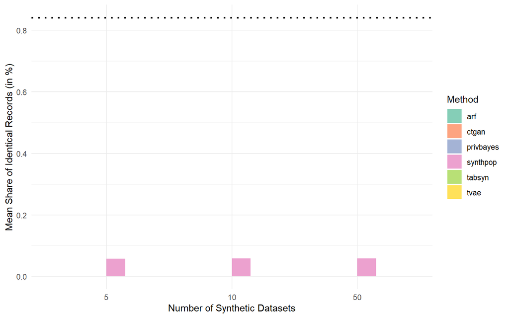

```r
plot_medical_insurance_sir <- ggplot(more_criteria_medical_insurance_mean_sir, aes(x = factor(M), y = Mean_IMS_Train_Syn, fill = Method)) +
  geom_bar(stat = "identity", position = "dodge", alpha = 0.8) +
  geom_hline(yintercept = mean(more_criteria_medical_insurance_mean_sir$Mean_IMS_Train_Test),
             linetype = "dotted", color = "black", size = 1) +
  theme_minimal() +
  labs(
    x = "Number of Synthetic Datasets",
    y = "Mean Share of Identical Records (in %)"
  ) +
  scale_fill_manual(values = c("#66C2A5", "#FC8D62", "#8DA0CB", "#E78AC3", "#a6d854", "#FFD92F")) +
  theme(legend.position = "right")
plot_medical_insurance_sir
```

Key observations

- ARF, CTGAN, PrivBayes and TVAE have no identical records at all (SIR = 0)
- Synthpop has SIR, but not too much (~ 0.06%)

## Distance to closest records (DCR)

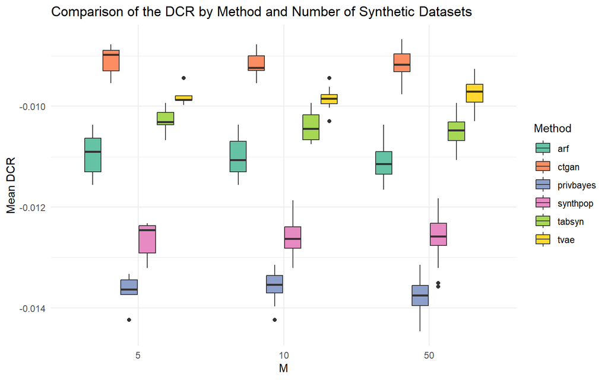

```r
# Boxplot erstellen
plot_medical_insurance_dcr <-ggplot(more_criteria_medical_insurance_dcr, aes(x = factor(M), y = DCR, fill = Method)) +
  geom_boxplot() +
  labs(title = "Comparison of the DCR by Method and Number of Synthetic Datasets",
       x = "M",
       y = "Mean DCR") +
  theme_minimal() +
  scale_fill_brewer(palette = "Set2")
plot_medical_insurance_dcr
```

In general: The distances between synthetic data and training data should not be systematically smaller than between training and holdout data.

Interpretation:

- The DCR values are small negative numbers.
- Since DCR is calculated as the difference between the minimum distances to the training and holdout sets, a negative value suggests that, on average, synthetic records are slightly closer to the holdout set than to the training set.
- This could indicate that the synthetic data captures the distribution well and does not overfit to the training data.
- More negative values may indicate potential overfitting to the training data.
- -> When the difference is negative, then the distances between synthetic data and training data are not systematically smaller than between training and holdout data
- -> good

## Nearest-neighbor distance ratio (NNDR)

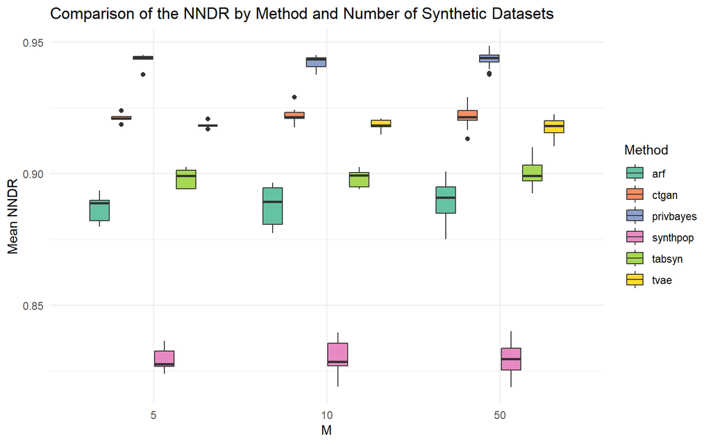

```r
# Boxplot erstellen
plot_medical_insurance_nndr <- ggplot(more_criteria_medical_insurance_nndr, aes(x = factor(M), y = Mean_NNDR_Filtered, fill = Method)) +
  geom_boxplot() +
  labs(title = "Comparison of the NNDR by Method and Number of Synthetic Datasets",
       x = "M",
       y = "Mean NNDR") +
  theme_minimal() +
  scale_fill_brewer(palette = "Set2")
plot_medical_insurance_nndr
```

Interpretation in general:

- NNDR close to 1: The nearest and second-nearest neighbors are almost equally distant, meaning the synthetic data does not strongly resemble a specific real point. Suggests good privacy.
- NNDR close to 0: The nearest neighbor is much closer than the second-nearest, meaning the synthetic data point is highly similar to one real data point. This suggests higher privacy risk.
- Moderate NNDR: More balanced privacy and resemblance